# Algorithm Class 25 - Practice 15

Integers and Strings

June/28/2019

# 1 Bit Representation For Integers

## 1.1 Basic Knowledge

How are integers represented in bits in Java?

1. **Most significant bit** (the **leftmost** bit):

- The sign bit, determines whether the number is positive or negative. (There is no unsigned type in Java)

2. Two’s complements:

0: (all zero)

```
00000000 00000000 00000000 00000000
```

5:

- sign bit is 0

```
5 = 1 * 2^0 + 0 * 2^1 + 1 * 2^2
```

- from least significant bit (the rightmost bit) to left

```
00000000 00000000 00000000 00000101
```

-5:

- sign bit is 1, “complement of 5” + 1

```
00000000 00000000 00000000 00000101: +5 原碼
10000000 00000000 00000000 00000101: -5 原碼
11111111 11111111 11111111 11111010: ones' complement 反碼
11111111 11111111 11111111 11111011: two's complement 補碼
```

A little bit more about ones’ complement and two’s complement:

- ones’ complement: defined as the complement with respect to 2^N - 1:

```
x + -x's complement = 1111...1111
                        N * 1s
```

- two’s complement: defined as the complement with respect to 2^N:

```
x + -x's complement + 1 = 10000...0000 = 0000...0000
                             N * 0s        N * 0s
```

- ones’ complement can only represent $-(2^{N-1}-1)$ to $(2^{N-1}-1)$ using N bits.
- two’s complement can represent $-(2^{N-1})$ to $(2^{N-1}-1)$ using N bits.

Example: (4-bits)

| . | min | max | count |
| --- | --- | --- | --- |
| 原碼 | 1111 (-7) | 0111 (7) | 15 |
| 反碼 | 1000 (-7) | 0111 (7) | 15 |
| 補碼 | 1000 (-8) | 0111 (7) | 16 |

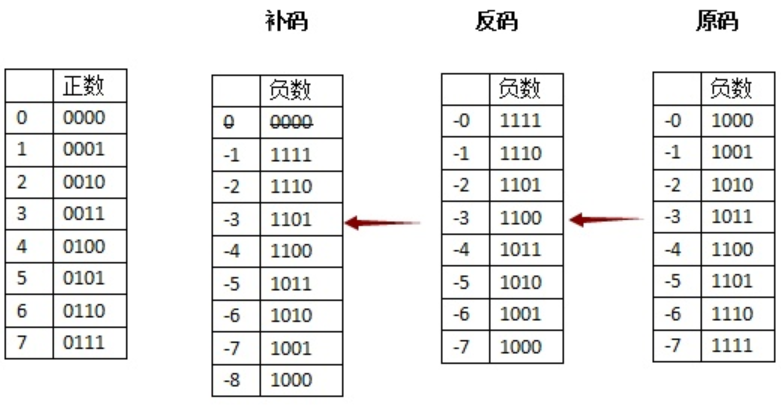

## 1.2 Test

```java
public class Bit {
  // print binary representation of a int value
  public static void printBinary(int value) {
    System.out.println(value + " : ");
    StringBuilder builder = new StringBuilder();
    for (int shift = 31; shift >= 0; shift--) {
      builder.append((value >>> shift) & 1);
    }
    System.out.println(builder.toString());
    System.out.println();
  }

  public static void main(String[] args) {
    // 0
    int a = 0;
    printBinary(a);

    // positive number
    a = 5;
    printBinary(a);

    // negative number
    a = -5;
    printBinary(a);

    a = Integer.MIN_VALUE;
    printBinary(a);
    // 10000000 00000000 00000000 00000000

    a = Integer.MAX_VALUE;
    printBinary(a);
    // 01111111 11111111 11111111 11111111

    // Integer.MAX_VALUE + 1 = Integer.MIN_VALUE;
    // Integer.MIN_VALUE - 1 = Integer.MAX_VALUE;

    // all "1"
    a = -1;
    printBinary(a);
    // 11111111 11111111 11111111 11111111

    // signed shift - leftmost bit depends on previous leftmost bit
    int b = a >> 5;
    printBinary(b);

    // unsigned shift - leftmost bit "0"
    b = a >>> 5;
    printBinary(b);
  }
}
```

## 1.3 `>>>` v.s. `>>`

### 1.3.1 Signed shift `>>`: arithmetical

The leftmost position after signed shift depends on sign extension (the most significant bit):

```
1 0 1 1 0 0 0 0 0 ... 1 1 0 1 0 1
  <_______________________> - - -
>> 3
1 1 1 1 0 1 1 0 0 0 0 0 ... 1 1 0
  + + + <_______________________>
```

### 1.3.2 Unsigned shift `>>>`: logical

The unsigned right shift operator `>>>` shifts a **zero** into the left most position

```
1 0 1 1 0 0 0 0 0 ... 1 1 0 1 0 1
<_________________________> - - -
>>> 3
0 0 0 1 0 1 1 0 0 0 0 0 ... 1 1 0
+ + + <_________________________>
```

### 1.3.3 Summary

Note: There is no “unsigned int” in Java before Java 8, but there is unsigned right shift.

Two views of a int:

- 32 bits, each of which is either 0 or 1
- Arithmetic number (either signed or unsigned in Java 8)

http://stackoverflow.com/questions/1023373/findbugs-warning-integer-shift-by-32-what-does-it-mean

# 2 Integers: Autoboxing and Unboxing

## 2.1 Primitive type v.s. Wrapper class

- `int`: `Integer`
- `long`: `Long`
- `char`: `Character`
- `double`: `Double`
- `boolean`: `Boolean`
- …

A wrapper class is just a wrapper of the corresponding primitive type, the Object representation of primitive type values.

**Similar to String, all the wrapper class objects are IMMUTABLE: internal values cannot be changed after initialization.**

It can help:

1. Generic type cannot be primitive type, `List<Integer>`, there cannot be `List<int>`
2. It can help provide useful functionalities and contracts (json serializer: obj -> json)
3. How do you represent a “non existed” int value? “null”

**In industry, always prefer primitive types to wrapper classes. (Extra overhead)**

Example (`Integer`):

```java
class Integer implements Comparable<Integer> {
  private final int value;  // wrap the primitive type value inside
  public Integer(int value) {
    this.value = value;
  }

  public int intValue() {
    return value;
  }

  public Integer plus(Integer another) {
    return Integer.valueOf(value + another.intValue());
  }

  @Override
  public int compareTo(Integer another) {
    if (value == another.value) {
      return 0;
    }
    return value < another ? -1 : 1;
  }
  // ...
}
```

```java
Integer a = 1;  // a -> object1(1)
a = 2;  // a -> object2(2)
```

## 2.2 Autoboxing (裝箱)

Autoboxing is the automatic conversion that the Java compiler makes between the primitive types and their corresponding object wrapper classes.

For Example, converting an `int` to an `Integer`, a `double` to a `Double`, and so on.

```java
List<Integer> integerList = new ArrayList<Integer>();
for (int i = 0; i < 50; i++) {
  integerList.add(i); // ==> integerList.add(Integer.valueOf(i));
}
```

## 2.3 Unboxing (拆箱)

Unboxing is the reverse operation of autoboxing.

Example:

```java
Integer a = 4;  // autoboxing => Integer a = Integer.valueOf(4);
a += 4; // a = a + 4
a++;
```

What happened when `Integer++`?

- `Integer` is immutable, the `int` value of the `Integer` object can never change

`a++`:

```java
int temp = a.intValue();
temp++;
a = Integer.valueOf(temp);  // a is pointing ro another Integer object
```

`a += 4`:

```java
int temp = a.intValue();
temp += 4;
a = Integer.valueOf(temp);  // a is pointing ro another Integer object
```

**More Examples:**

**Note: `+`, `-`, `*`, `/`, `>`, `<`, `>=`, `<=`, … only applied to primitive type.**

```java
Integer a = 5;  // autoboxing
int b = 5;  // primitive
System.out.println(a > b);  // false, unboxing -> a.intValue() > b
System.out.println(a + 2);  // 7
System.out.println(a * 3);  // 15
System.out.println(a == b); // true, unboxing

Integer c = 5;
System.out.println(a > c);  // false, unboxing -> a.intValue() > c.intValue()
```

**`==` both operand can be Object type and it is comparing if the two references are pointed to the same Object**

```java
Integer a = 5;  // Integer.valueOf(5);
Integer c = 5;  // Integer.valueOf(5);
System.out.println(a > c);  // false
System.out.println(a > c);  // true
System.out.println(a == c); // true

Integer a = 128;  // Integer.valueOf(128);
Integer c = 128;  // Integer.valueOf(128);
System.out.println(a > c);  // false
System.out.println(a > c);  // true
System.out.println(a == c); // false
```

- Integer class cache the Integer object with value from -128 to 127, so every time an Integer object within this range is needed, it will always return the corresponding object.

*More Notes Pending*

## 2.4 Comparators Revisited

When you implement your own Comparator or override `equals()`, keep in mind:

- Be very careful if you see `==` on Object type.

Bad Example:

```java
class MyComparator implements Comparator<Integer> {
  @Override
  public int compare(Integer i1, Integer i2) {
    if (i1 == i2) {
      return 0; // we do not want to check the references
    }
    return i1 < i2 ? -1 : 1;
  }
}
```

How to correct the above code? Use the following 4 methods:

```java
return i1.compareTo()i2;  // return Integer.compare(i1, i2);
```

```java
if (i1.equals(i2)) {}
```

```java
if (i1.intValue() == i2.intValue()) {}
```

```java
@Override
public int compare(Integer i1, Integer i2) {
  if (i1 < i2) {
    return -1;
  }
  else if (i1 > i2) {
    return 1;
  }
  return 0;
}
```

But not using this: (It could overflow!!!)

```java
class MyComparator implements Comparator<Integer> {
  @Override
  public int compare(Integer i1, Integer i2) {
    return i1 - i2;
  }
}
```

Using the following to correct:

```java
class MyComparator implements Comparator<Long> {
  @Override
  public int compare(Long l1, Long l2) {
    if (l1 < l2) {
      return -1;
    }
    else if (l1 > l2) {
      return 1;
    }
    return 0;
  }
}
```

# 3 Strings

A sequence of characters “abc”.

In Java, they are objects.

```java
class String {

}
char[] array = {'a', 'b', 'c', 'd'};
offset = 1; count = 2;  // array(1, 2); -> "bc"
```

## 3.1 Creating Strings

String literal:

- A series of characters in your code that is enclosed in double quotes “abc”

Whenever it encounters a string literal in your code, the compiler creates a String Object with its value (really?)

```java
String s1 = "abc";
String s2 = "abc";
System.out.println(s1 == s2); // true -> 常量池
String s3 = new String("abc");
System.out.println(s1 == s3); // false
```

The String objects created with “new” will not use the intern pool.

**Pooling for String objects**

There is no need for maintaining several copies of String objects with the same literal, since String objects are immutable.

Usually compiler and JVM will optimize for the number of String objects created, it will maintain an intern area in HEAP, for the same String literal it will only has one String object associated. [String link 1](http://tech.meituan.com/in_depth_understanding_string_intern.html) [String link 2](http://cymoft.blog.51cto.com/324099/473220/)

```java
String sa = "a";
String sb = "b";
String sab = "a" + "b"; // compile time concat, "ab"

System.out.println(sab == "a" + "b");
System.out.println(sab == "ab");
System.out.println(sab == sa + "b");
System.out.println(sab == sa + sb);
```

```
true
true
false
false
```

```java
System.out.println(sab.equals("a" + "b"));
System.out.println(sab.equals("ab"));
System.out.println(sab.equals(sa + "b"));
System.out.println(sab.equals(sa + sb));
```

```
true
true
true
true
```

The optimization is at compile time, the literals will be concatenated if possible before getting the String object.

Constructors: http://docs.oracle.com/javase/7/docs/api/java/lang/String.html

- `String()`
- `String(String value)`
- `String(char[] array)`
- `String(char[] array, int offset, int length)`
- `String(StringBuilder builder)`

## 3.2 Immutability

The value of the String object cannot be changed after creation.

```java
String s1 = "abc";
String s2 = s1;
```

```java
// this is another String object, the previous object's value is not changed
s2 = "def";
```

```java
System.out.println(s1); // "abc"
System.out.println(s2); // "def"
```

## 3.3 String Length

`s1.length()` v.s. `int[].length`

## 3.4 Concatenate Strings

- `s1.concat(s2)`: again, this will create a new String object rather than change the value of s1 or s2.
- `s1 = "abc" + "def";`: 等價於`s1 = "abcdef"`, compile time concatenation.
- `s1 = s1 + "def";`: `s1.concat("def");`
- `s1 = 1 + "def";`: `String.valueOf(1),` (1 -> Integer(1) -> Integer(1).toString()) -> “1”
- `s1 = "id: " + 2 + "isStudent: " + true + "y";`: could be further optimized to `new StringBuilder().append("id: ").append(2).append("isStudent: ").append(true).append("y").toString()` at compile time.
  - Time: O($nm$)
  - Space: O($nm$)

## 3.5 Converting Number to/from Strings

1. TO:

- primitive type:

```java
int i = 0;

// Method 1
String si = i + ""; // "0"

// Method 2
si = String.valueOf(i);

// Method 3
si = Integer.toString(i);
```

- wrapper class:

```java
Integer integer = null;

// Method 1 (not recommended)
si = integer.toString();  // will cause NPE when dereferencing null

// Method 2
si = String.valueOf(integer); // if integer is null, si = "null"
```

2. FROM

```java
String si = "11";

// Method 1
Integer.valueOf(si);  // return Integer

// Method 2
Integer.parseInt(si); // return int
```

3. For other primitive types as well

- Byte, Short, Long, Float, Double, Integer, Boolean

## 3.6 Chars and Substrings

`String substring(int beginIndex, int endIndex)`

- The substring begins at the specified `beginIndex` and extends to the character at index `endIndex - 1`. Thus the length of the substring is `endIndex - beginIndex`.
- `endIndex` is **exclusive**.

`String substring(int beginIndex)`

- `endIndex = length()`

return new String object representing part of the original String.

- Before Java 7u6, it is reusing the char array maintained by the original String, and maintain an offset for the index to start with. O($1$), old object cannot be gc-ed.
- After Java 7u6, it will make a copy of the part of the original String’s char array. ~O($n$), old object can be gc-ed.
- http://stackoverflow.com/questions/2147783/why-does-appending-to-a-string-save-memory/2147803#2147803

*More Notes Pending*

## 3.7 `equals` v.s. `==`

*More Notes Pending*

## 3.8 String

*More Notes Pending*

## 3.9 `StringBuilder`, `StringBuffer`

*More Notes Pending*